# R Notebook

R markdown notabook สามารถสร้างเอกสารได้หลากหลาย format เช่น html, pdf, word โดยผู้ใช้เพียงแค่หัดเขียน markdown language ให้เป็นก็พอแล้ว ซึ่งเป็นจุดเด่นทำให้คนทั่วๆไปที่ไม่ใช่ software developer ไม่ต้องลำบากในการทำรายงานสรุปผลมากนัก

Shortcut เบื้องต้น

```
Ctrl+Shift+Enter: Run Current Chunk
Ctrl+Alt+I: สร้าง Chunk ใหม่สำหรับเขียน R code
Ctrl+Shift+K: Preview สร้าง output ของเอกสารเช่น HTML (ตั้งค่า output ที่บริเวณบรรทัดแรกๆของไฟล์)
```

การเพิ่ม packages ใหม่ให้ RStudio ทำได้โดย  
`Tools > Install packages > add packages name to packages box`  
ตัวอย่าง packages ที่ใช้งานบ่อยๆเช่น  
`MASS gplots ggplot2 gtable data.table dataframes2xls httr XML xml2 curl rvest plyr rjson dplyr ggally ggpairs reshape2`

หรืออาจใช้ R console ช่วยในการติดตั้งด้วยคำสั่งดังนี้

```
install.packages(c("MASS", "gplots", "ggplot2", "gtable","data.table", "dataframes2xls", "httr", "XML", "xml2", "curl", "rvest", "plyr", "rjson", "dplyr", "ggally", "ggpairs", "reshape2"),
repos = "http://cran.r-project.org")
```

### Test plot

Note: ตัวแปร cars ถูกใส่ค่ามาให้อัตโนมัติจาก `packages:datasets`

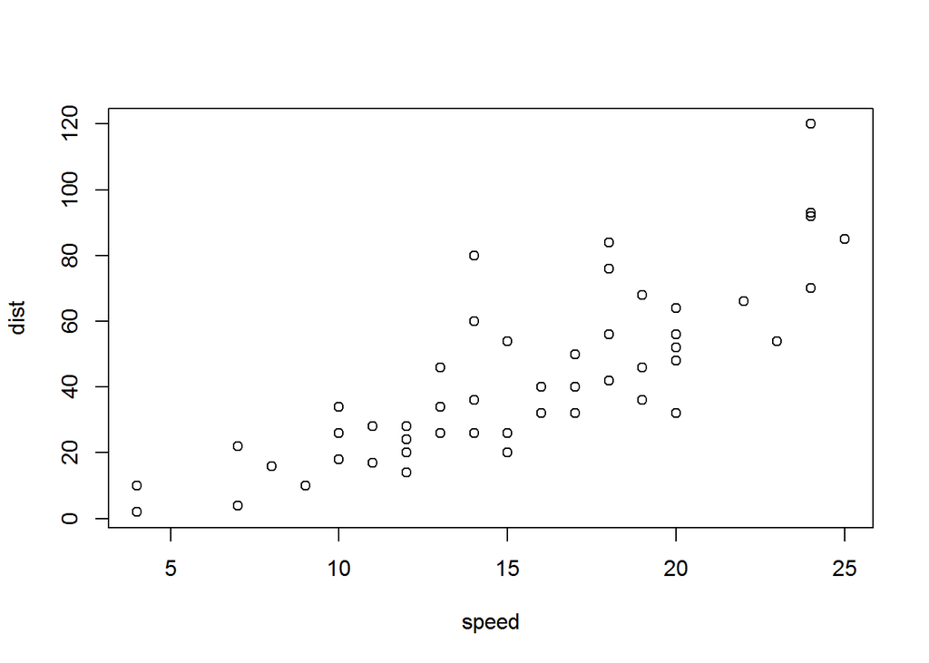

```r
plot(cars)
```

### Test scrap data from online table

```r
library(data.table)
library(XML)

airline = "http://www.theacsi.org/benchmarks-by-industry-14729"
airline.table = readHTMLTable(airline, header=T, which=1, stringsAsFactors=F)
View(airline.table)
```

### ประเภทข้อมูลใน R

**vector**: เป้นข้อมูลมิติเดียว มีได้ตั้งแต่ 1 ตัวขึ้นไปแต่จะต้องเป็น atomic object ประเภทเดียวกันทั้งหมดเช่น character, complext number, numeric, interger, logical(True/False)  
สามารถใช้ตัวอักษร c(concatenate) เพื่อระบุว่าเป็น vector ได้ตัวอย่างเช่น

```r
myvector <- c(1,2,3) # same as: myvector = c(1,2,3)
myvector
```

```
## [1] 1 2 3
```

จาก output `[1] 1 2 3` ค่า [1] หมายถึงเป็นตัวแปรแบบ 1 มิติ

**list**  
คล้าย vector แต่สามารถนำข้อมูลต่างชนิดมาใส่ในลิสเดียวกันได้

```r
mylist <- list('Dog', 30, 1.23)
mylist
```

```
## [[1]]
## [1] "Dog"
##
## [[2]]
## [1] 30
##
## [[3]]
## [1] 1.23
```

**matrix**: เป็นข้อมูลหลายมิติที่ข้อมูลทุกตัวจะต้องเป็น object ชนิดเดียวกันทั้งหมด  
**data frame**: ข้อมูลหลายมิติที่สามารถกำหนดให้ข้อมูลต่าง column กันเป็น type ที่ไม่เหมือนกันได้  
สามารถเข้าถึงข้อมูลใน data frame ทั้ง column ที่ต้องการได้ดังนี้ `mytable$Name` หรือ `mytable[['Name']]` อีกทั้งยังอ้างอิงไประดับลึกลงไปได้เช่น `mytable$items[2] เป็นต้น

```r
cars$speed[2]
```

```
## [1] 4
```

### basic read file

หากไฟล์ถูกเก็บอยู่ในรูปแบบ tab delimites สามารถอ่านข้อมูลเข้ามาได้ทันที

```r
input_dat <- read.table("res/users_tabdelimited.txt")
View(input_dat)
```

หากไฟล์ถูกแยกข้อมูลโดยใช้สัญลักษณ์ื่นเช่น “,” เช่นไฟล์ csv สามารถใช้ sep ได้ดังนี้

```r
input_dat <- read.table("res/input.csv", sep=",")
View(input_dat)
```

การอ่านข้อมูล string เข้ามาทีละย่อหน้า

```r
text <- readLines("res/bookshelf_poem.txt", encoding="UTF-8")
text[2]
```

```
## [1] " I like to think that when I fall,"
```

การวนลูปเพื่ออ่านไฟล์ทั้งหมด

```r
list.filenames <- list.files(path = "res", pattern = ".csv$")
list.data <- list()
for(idx in 1:length(list.filenames)){
  list.data[[idx]] <- read.csv(paste("res", list.filenames[idx], sep="/"))
}
View(list.data[1])
View(list.data[2])
```

สามารถใช้ `lapply()` แทนการเขียน loop list ตรงๆได้ดังนี้

```r
list.filenames <- list.files(path = "res", pattern = ".csv$")
list.data <- list()
list.data2 <- lapply(list.filenames, function(fname){
  read.csv(paste("res", fname, sep="/"))
})
View(list.data2[1])
View(list.data2[2])
```